-– title: “hw3” author: “Jess Kaminsky” date: “March 23, 2018” output: html_document —

## Jess Kaminsky- Homework 3 - PHP 2514

## GELMAN HILL CHAPTER 5 - QUESTION 3

$$\beta_0 = logit(0.27) = -0.9946\\
logit(.88) = -0.9946 + \beta_1 * 6\\
\beta_1 = 0.4978\\
logit(y) = -0.9946 + 0.4978x\\
y = logit^{-1}(-0.9946 + 0.4978x) = expit(-0.9946 + 0.4978x) = \frac{e^{-0.9946 + 0.4978x}}{1 + e^{-0.9946 + 0.4978x}}$$

## GELMAN HILL CHAPTER 5 - QUESTION 5

1. *Graph the fitted model. Also on this graph put a scatterplot of hypothetical data consistent with the information given.*

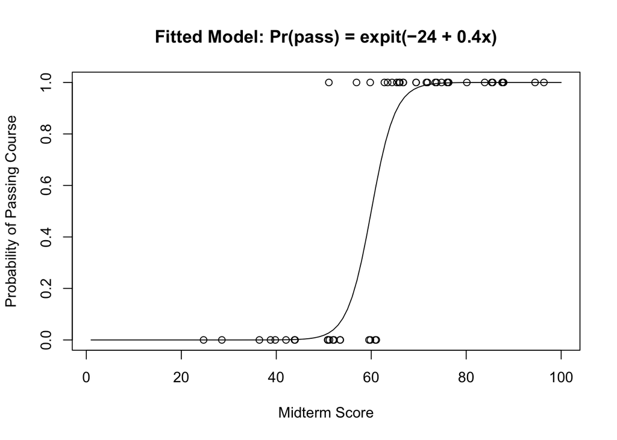

2. *Suppose the midterm scores were transformed to have a mean of 0 and stan-dard deviation of 1. What would be the equation of the logistic regressionusing these transformed scores as a predictor?*

In logistic regression, when the x’s are standardized, the intercept term disappears. The standardized coefficients can be found by multiplying the estimate of $\beta$ by the standard deviation of the x’s for that coefficient.
$$Standardized \beta_0 = 0\\
Standardized \beta_1 = \beta_1 * \sigma_{x1} = 0.4 * 15 = 6\\
logit(y) = 6x\\
y = logit^{-1}(6x) = expit(6x) = \frac{e^{6x}}{1 + e^{6x}}$$

3. When comparing the exact model predicting probability of passing from midterm score to a model with random noise added - the difference in residual deviance between the two models is close to 0. We can conclude that when a pure noise predictor is added the residual deviance should not decrease.

| Exact Model Deviance: | 2.53058109781162e-15 |
| --- | --- |
| Null Model Deviance: | 2.99859277594636e-15 |
| Difference in Deviance: | 4.68011678134743e-16 |

## GELMAN HILL CHAPTER 5 - QUESTION 8

1. *Build a logistic regression model to predict the presence of rodents (the variable rodent2 in the dataset) given indicators for the ethnic groups (race).Combine categories as appropriate. Discuss the estimated coefficients in the model.*

Below is the distribution of the race groups represented in our data set. Groups 6 and 7 are much smaller than the others - group 6 has only 7 subjects and group 7 has 10. We will continue the analysis by combining groups 6 and 7.

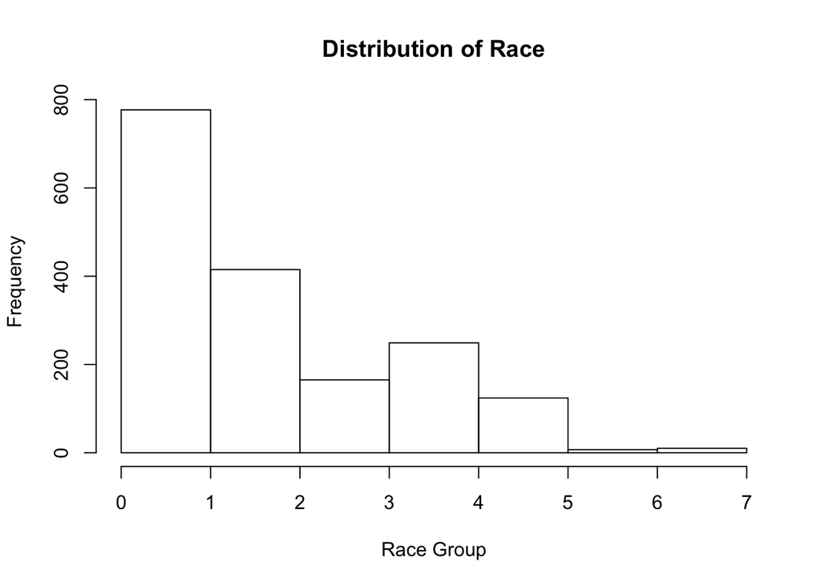

After Combining groups 6 + 7, the distribution of race is as follows.

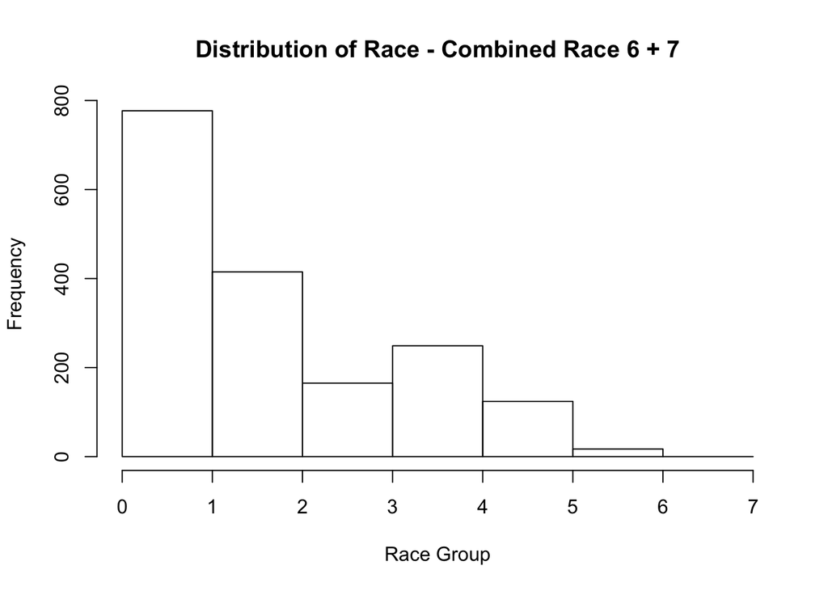

In building a logistic regression model predicting the presence of rodents from the indicator variable for ethnic group, we obtain the following model with race 1 as the reference group and race6 combining subjects from race groups 6 and 7.

```
##
## Call:
## glm(formula = rodent2 ~ race, family = binomial(logit), data = rodents)
##
## Deviance Residuals:
##     Min       1Q   Median       3Q      Max
## -1.0590  -0.8969  -0.4690  -0.4690   2.1270
##
## Coefficients:
##             Estimate Std. Error z value Pr(>|z|)
## (Intercept)  -2.1521     0.1281 -16.798  < 2e-16 ***
## race2         1.5361     0.1687   9.108  < 2e-16 ***
## race3         1.4492     0.2138   6.777 1.23e-11 ***
## race4         1.8671     0.1872   9.973  < 2e-16 ***
## race5         0.4004     0.2923   1.370   0.1708
## race6         1.3636     0.5544   2.460   0.0139 *
## ---
## Signif. codes:  0 '***' 0.001 '**' 0.01 '*' 0.05 '.' 0.1 ' ' 1
##
## (Dispersion parameter for binomial family taken to be 1)
##
##     Null deviance: 1672.2  on 1521  degrees of freedom
## Residual deviance: 1520.2  on 1516  degrees of freedom
##   (225 observations deleted due to missingness)
## AIC: 1532.2
##
## Number of Fisher Scoring iterations: 4
```

2. *For the second part of this problem use the variables in the dataset to develop a good logistic regression model. Make sure to carefully explain what your final model means and check its fit using diagnostics. Make an ROC plot and a calibration curve.*

In order to determine the most efficient logistic model for predicting the probability of rodent infestation, we will use stepwise regression with AIC. The resulting model is as follows:
$$logit(p) = -5.905 + 0.8672(personrm) - 0.0069(housewgt) + 0.2373(cd) -0.4553(regext1) + 0.3534(povertyx2) + 1.056(extflr5_2)\\ + 0.8981(intcrack2) + 0.7164(inthole2) + 0.4490(intleak2) - 0.8904(struct) - 0.5628(help) + 2.057(blackMean) + 4.086(helpMean)\\ + 2.900(hispanicMean) + 1.4730(oldsMean) + 1.966(regextMean) + 7.509(dilapMean) - 16.29(intcrack2Mean) + 19.48(inthole2Mean) - 0.0014(bldg)$$

```r
summary(rodent_best)
```

```
##
## Call:
## glm(formula = rodent2 ~ personrm + housewgt + cd + regext + povertyx2 +
##     extflr5_2 + intcrack2 + inthole2 + intleak2 + struct + help +
##     black_Mean + help_Mean + hispanic_Mean + old_Mean + regext_Mean +
##     dilap_Mean + intcrack2_Mean + inthole2_Mean + bldg, family = binomial(logit),
##     data = rodent_na)
##
## Deviance Residuals:
##     Min       1Q   Median       3Q      Max
## -2.1089  -0.7121  -0.4353   0.6942   2.4711
##
## Coefficients:
##                  Estimate Std. Error z value Pr(>|z|)
## (Intercept)    -5.905e+00  1.854e+00  -3.185 0.001447 **
## personrm        8.672e-01  2.344e-01   3.700 0.000216 ***
## housewgt       -6.902e-03  2.508e-03  -2.753 0.005911 **
## cd              2.373e-01  7.800e-02   3.042 0.002350 **
## regext1        -4.553e-01  1.983e-01  -2.295 0.021707 *
## povertyx21      3.534e-01  1.981e-01   1.784 0.074357 .
## extflr5_21      1.056e+00  4.945e-01   2.136 0.032651 *
## intcrack21      8.981e-01  2.666e-01   3.369 0.000756 ***
## inthole21       7.164e-01  3.435e-01   2.085 0.037030 *
## intleak21       4.490e-01  2.259e-01   1.988 0.046823 *
## struct1        -8.904e-01  2.087e-01  -4.266 1.99e-05 ***
## help1          -5.628e-01  2.300e-01  -2.447 0.014411 *
## black_Mean      2.057e+00  5.635e-01   3.650 0.000263 ***
## help_Mean       4.086e+00  1.986e+00   2.057 0.039651 *
## hispanic_Mean   2.900e+00  6.978e-01   4.156 3.24e-05 ***
## old_Mean        1.473e+00  6.934e-01   2.125 0.033607 *
## regext_Mean     1.966e+00  8.682e-01   2.264 0.023576 *
## dilap_Mean      7.509e+00  3.135e+00   2.395 0.016598 *
## intcrack2_Mean -1.629e+01  5.074e+00  -3.210 0.001329 **
## inthole2_Mean   1.948e+01  7.065e+00   2.758 0.005819 **
## bldg           -1.444e-03  4.561e-04  -3.166 0.001547 **
## ---
## Signif. codes:  0 '***' 0.001 '**' 0.01 '*' 0.05 '.' 0.1 ' ' 1
##
## (Dispersion parameter for binomial family taken to be 1)
##
##     Null deviance: 918.58  on 743  degrees of freedom
## Residual deviance: 695.42  on 723  degrees of freedom
## AIC: 737.42
##
## Number of Fisher Scoring iterations: 5
```

Model Diagnostics for stepwise generated logistic regression model

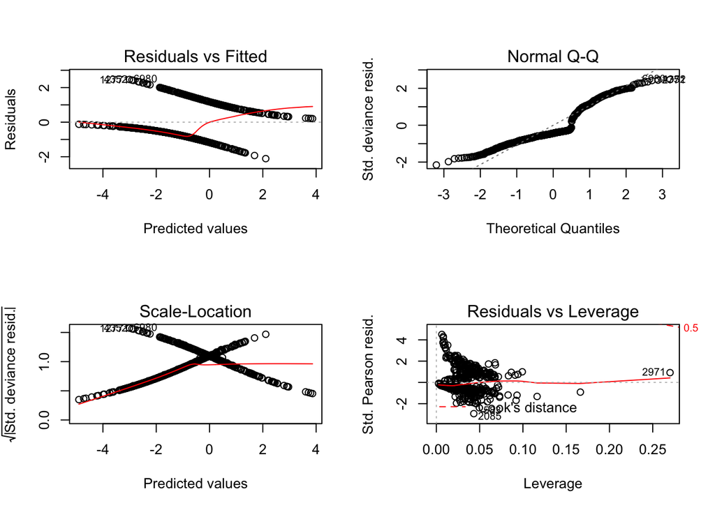

ROC Plot for stepwise generated logistic regression model

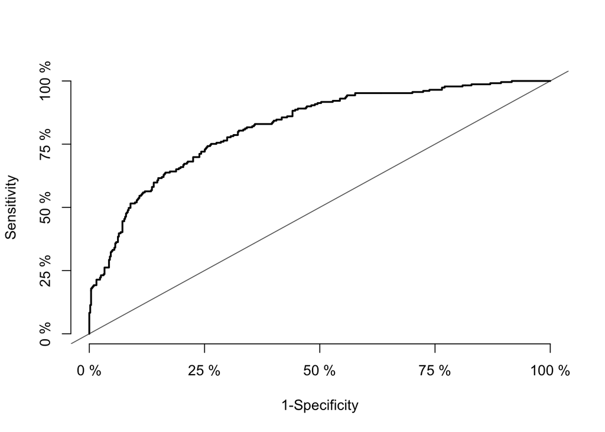

Calibration Plot for stepwise generated logistic regression model

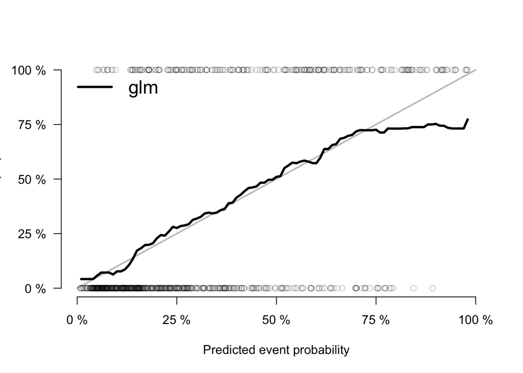

## QUESTION 4

A summary of the results generated from building a proportional odds regression model predicting dehydration level from clinical signs is presented below.

```
## Call:
## multinom(formula = dehyd ~ capref + extrem + eyes + genapp +
##     heart + mucous + pulse + resp + tears + thirst + urine, data = dhaka,
##     family = cumulative(parallel = FALSE))
##
## Coefficients:
##   (Intercept)   capref1   extrem1     eyes1    eyes2   genapp1  genapp2
## 1   0.5567544 18.491564 0.3599837 0.3831114 1.387400 0.7384606 1.468699
## 2 -15.9103269 -6.612274 0.9937428 0.2873533 2.127023 0.3841184 1.761417
##      heart1    heart2    mucous1   mucous2    pulse1   pulse2     resp1
## 1 0.5551484 -7.276072 -0.1990252  16.23977 0.6372741 1.775578 0.6614680
## 2 0.1789334 24.381440  0.4570814 -14.59949 1.0057926 2.029788 0.2343428
##      resp2    tears1     tears2   thirst1   thirst2     urine1    urine2
## 1 15.54951 0.2426326 0.07766233 -1.818225 -2.149638 0.06206169 0.1767247
## 2 15.11407 0.1759756 0.96972757 11.984377 12.004204 1.02636266 0.5792596
##
## Std. Errors:
##   (Intercept)      capref1   extrem1     eyes1    eyes2   genapp1
## 1   1.2335970 6.982519e-10 0.8814896 0.3701585 0.699653 0.3258073
## 2   0.6240915 6.206011e-13 0.9758170 0.8166879 1.027610 0.5752896
##     genapp2    heart1    heart2   mucous1   mucous2    pulse1   pulse2
## 1 0.4558329 0.3298399 0.4445444 0.3009165 0.4445444 0.3903115 1.107517
## 2 0.5964699 0.4834979 0.4445440 0.5637185 0.4445440 0.5330544 1.199036
##       resp1     resp2    tears1    tears2   thirst1  thirst2    urine1
## 1 0.3750403 0.4789797 0.2977649 0.7587668 1.2029976 1.327002 0.2864949
## 2 0.5301760 0.4789797 0.4981013 0.8885670 0.3687684 0.550298 0.5736418
##      urine2
## 1 0.4544834
## 2 0.7650857
##
## Residual Deviance: 587.3074
## AIC: 671.3074
```

The two models generated from the preceeding output are:

$$ln(p(dehyd = 1 / dehyd = 0)) = 0.5567 + 18.491(capref1) + 0.3599(extrem1) + 0.3831(eyes1) + 0.7384(genapp1) + 0.5551(heart1)\\ - 0.199(mucous1) + 0.6372(pulse1) + 0.6614(resp1) + 0.2426(tears1) - 1.8182(thirst1) + 0.0621(urine1)\\ + 1.3874 (eyes2) + 1.4686(genapp2) - 7.276(heart2) + 16.2398(mucous2) + 1.775 (pulse2) + 15.549(resp2) + 0.0776(tears2)\\ - 2.149(thirst2) + 0.1767(urine2)$$

$$ln(p(dehyd = 2 / dehyd = 0)) = -15.91 - 6.612(capref1) + 0.9937(extrem1) + 0.2873(eyes1) + 0.3841(genapp1) + 0.1789(heart1)\\ + 0.4571(mucous1) + 1.0057(pulse1) + 0.2343(resp1)+ 0.1759(tears1) + 11.984(thirst1) + 1.0264(urine1)\\ + 2.127(eyes2) + 1.7614(genapp2) + 24.3814(heart2) - 14.599(mucous2) + 2.0298(pulse2) + 15.1141(resp2) 0.9697(tears2)\\ + 12.0042(thirst2) + 0.5792(urine2)$$

We can interpret from these models that: - Patients with extrem = 1 have $e^{\beta _{extrem}} = e ^ {0.3599} = 1.4332$ times the risk of being dehyd = 1 compared to deyd = 0. - Patients with extrem = 1 have $e^{\beta _{extrem}} = e ^ {0.9937} = 2.70121$ times the risk of being dehyd = 2 compared to deyd = 0.

- Patients with genapp = 1 have $e^{\beta _{genapp}} = e ^ {0.7384} = 2.092$ times the risk of being dehyd = 1 compared to deyd = 0.
- Patients with genapp = 1 have $e^{\beta _{genapp}} = e ^ {0.3841} = 1.46$ times the risk of being dehyd = 2 compared to deyd = 0.
- Patients with tears = 1 have $e^{\beta _{tears}} = e ^ {0.2426} = 1.274$ times the risk of being dehyd = 1 compared to deyd = 0.
- Patients with tears = 1 have $e^{\beta _{tears}} = e ^ {0.1759} = 1.192$ times the risk of being dehyd = 2 compared to deyd = 0.

For my final model, I have decided to include all clinical signs as well as the variables for number of episodes and days of diarrhea. Based on our outcome - dehydration - I have also chosen to include episodes and diarrhea because they seem like logical predictors.

A summary of the 2 resulting proportional odds models are shown below. This model fits slightly better than the model with clinical signs only - the residual deviance has decreased.

```
## Call:
## multinom(formula = ordered(dehyd) ~ capref + extrem + eyes +
##     genapp + heart + mucous + pulse + resp + tears + thirst +
##     urine + daysofdiar + episodes, data = dhaka, family = cumulative(parallel = TRUE))
##
## Coefficients:
##   (Intercept)   capref1   extrem1     eyes1    eyes2   genapp1  genapp2
## 1   0.3123119 16.446867 0.1958852 0.4071632 1.504643 0.6992560 1.372129
## 2 -15.4140423 -5.595288 0.8709363 0.3444834 2.324079 0.2951736 1.556967
##      heart1    heart2    mucous1   mucous2    pulse1   pulse2     resp1
## 1 0.5750825 -4.552599 -0.2007529  16.17704 0.7620267 1.636512 0.5936332
## 2 0.1613358 27.040355  0.4982520 -14.57206 1.1802775 1.826817 0.1833963
##      resp2    tears1    tears2   thirst1   thirst2     urine1     urine2
## 1 15.40500 0.2506281 0.1635619 -1.876186 -2.287384 0.02741637 0.09719784
## 2 14.99852 0.1705507 0.9660649 10.671238 10.613805 1.04428945 0.57142195
##   daysofdiar   episodes
## 1 -0.0817346 0.03510019
## 2 -0.1319371 0.06695016
##
## Std. Errors:
##   (Intercept)      capref1   extrem1     eyes1     eyes2   genapp1
## 1   1.2724560 5.608845e-09 0.8720885 0.3748249 0.7124881 0.3289507
## 2   0.7613818 1.265207e-11 0.9649455 0.8244201 1.0450074 0.5834613
##     genapp2    heart1    heart2   mucous1   mucous2    pulse1   pulse2
## 1 0.4602586 0.3333525 0.4662482 0.3040543 0.4662482 0.3995500 1.110715
## 2 0.6069912 0.4949113 0.4662481 0.5703320 0.4662481 0.5465951 1.206466
##       resp1     resp2    tears1   tears2   thirst1   thirst2    urine1
## 1 0.3841102 0.4910283 0.3011162 0.783850 1.2139807 1.3417541 0.2904269
## 2 0.5471152 0.4910283 0.5045150 0.925571 0.4213579 0.5994838 0.5849732
##      urine2 daysofdiar   episodes
## 1 0.4598987 0.06680686 0.01681329
## 2 0.7754426 0.11427848 0.02369816
##
## Residual Deviance: 576.5883
## AIC: 668.5883
```

From the model above, we can interpret the following:

- Patients with eyes = 1 have $e^{\beta _{eyes}} = e ^ {0.4071} = 1.5024$ times the risk of being dehyd = 1 compared to deyd = 0.
- Patients with eyes = 1 have $e^{\beta _{eyes}} = e ^ {0.3444} = 1.4111$ times the risk of being dehyd = 2 compared to deyd = 0.
- Patients with eyes = 2 have $e^{\beta _{eyes}} = e ^ {1.5046} = 4.5024$ times the risk of being dehyd = 1 compared to deyd = 0.
- Patients with eyes = 2 have $e^{\beta _{eyes}} = e ^ {2.3241} = 10.2175$ times the risk of being dehyd = 2 compared to deyd = 0.
- For every 1 unit increase in days of diarrhea, the risk of being dehyd = 1 increases by a factor of $e^{\beta _{daysofdiar}} = e ^ {-0.0817} = 0.9215$ compared to dehyd = 0
- For every 1 unit increase in days of diarrhea, the risk of being dehyd = 2 increases by a factor of $e^{\beta _{daysofdiar}} = e ^ {-0.1320} = 0.8763$ compared to dehyd = 0
- For every 1 unit increase in episodes, the risk of being dehyd = 1 increases by a factor of $e^{\beta _{episodes}} = e ^ {0.0351} = 1.0357$ compared to dehyd = 0
- For every 1 unit increase in episodes, the risk of being dehyd = 2 increases by a factor of $e^{\beta _{episodes}} = e ^ {0.0669} = 1.0692$ compared to dehyd = 0